# Exercise 6

0316213 Yu-Wen Pu

2018-05-01

```r
knitr::opts_chunk$set(results = "hold", fig.retina = 2)
set.seed(1830)
```

##### 8.1

1. null hypothesis: 我說的是 hocky game 的分數。
2. 因為 hocky game 的分數不可能那麼高，所以這肯定不是 hocky game 的分數。reject null hypothesis。

##### 8.2

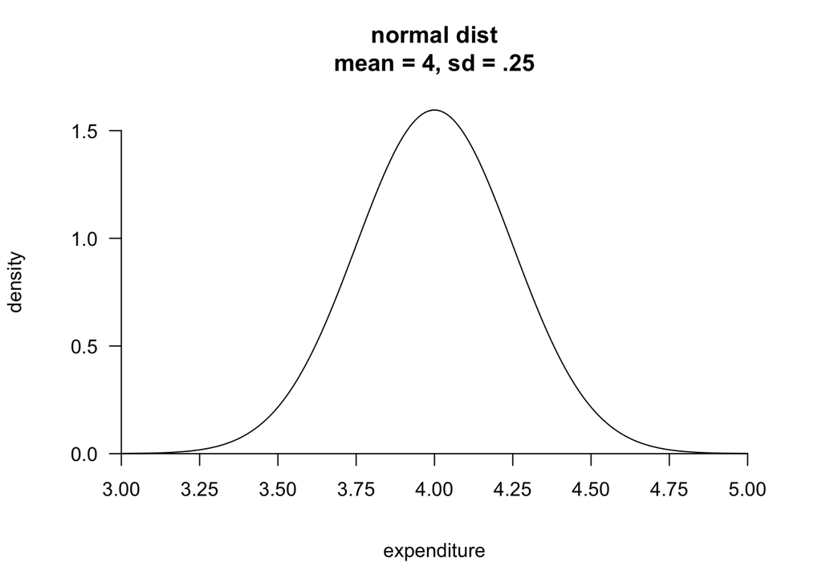

```r
x <- seq(from = 3, to = 5, by = .01)
plot(x, dnorm(x, mean = 4, sd = .25), type = "l",
     main = "normal dist\nmean = 4, sd = .25", xlab = "expenditure",
     ylab = "density", xaxt = "n", yaxt = "n", bty = "n")
axis(side = 1, seq(3, 5, .25), pos = 0, las = 0)
axis(side = 2, pos = 3, las = 2)
```

2. No.
3. 我花了 $4.25，跟平常差不多，還蠻正常的，沒理由擔心。

##### 8.3

Type I error: 我以為我有被多收錢或少收錢，但實際上我沒有。

##### 8.4

Type II error: 我以為我沒有被多收錢或少收錢，但實際上我有。

##### 8.5

- rejection region: 例如最高 5% 或最低 5%，花費落在這個區間，則 reject null hypothesis。
- critical value: rejection region 的邊界值稱為 critical value。

##### 8.10

sampling error: 樣本估計的統計量的誤差。

##### 8.11

- distribution: 任何變數的分佈。
- sampling distribution: 任何樣本統計量的分佈。

##### 8.14

```r
round(1 - pnorm(47.48, mean = 50, sd = 7), digits = 2)
```

```
## [1] 0.64
```

##### 8.15

```r
critical <- qnorm(.01, mean = 59, sd = 7)
round(1 - pnorm(critical, mean = 50, sd = 7), digits = 2)
```

```
## [1] 0.85
```

##### 8.18

1. research hypothesis (H1): 花錢會增加人們繼續看電影的意願。
2. null hypothesis (H0): 不論有沒有花錢，人們繼續看電影的意願都相同。
3. 取得有花錢的人的樣本（樣本統計量為 M）。
4. 取得沒花錢的人的 sampling distribution（H0 為真）。
5. 計算在 H0 為真的情況下，樣本統計量不小於 M 的機率（p 值）。
6. 依據 p 值大小，判斷是否要 reject null hypothesis。